# STAT462_ASSIGNMENT1

By Lin Huang Student ID 23074062

2023-03-20

```r
library(ggplot2)
library(tidyverse)
library(class)
library(kknn)
```

## Question 1.

### (a) Sketch the dataset.

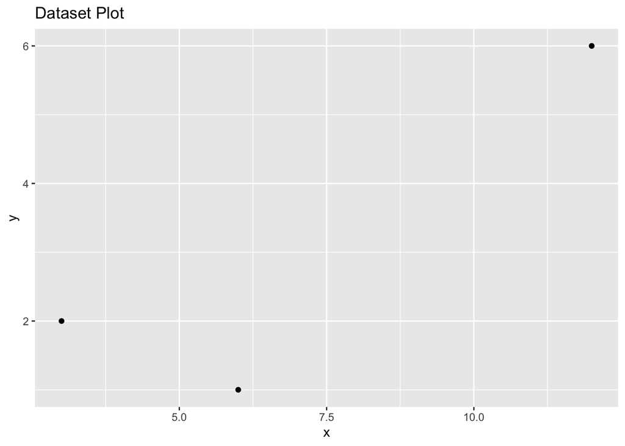

```r
# Create Dataset
df <- data.frame(x = c(3, 6, 12), y = c(2, 1, 6))
#Plot Dataset
p <-ggplot(df, aes(x, y)) + geom_point()+ggtitle("Dataset Plot") + xlab("x") + ylab("y")
p
```

### (b)

```r
#Compute beta0 and beta1
x_m <- mean(df$x)
y_m <- mean(df$y)
beta1 <- sum((df$x - x_m) * (df$y - y_m)) / sum((df$x- x_m)^2)
beta0 <- y_m - beta1 *x_m
#Use cat function to print
cat("beta1 = ", beta1, "\n")
```

```
## beta1 =  0.5
```

```r
cat("beta0 = ", beta0, "\n")
```

```
## beta0 =  -0.5
```

### (c)

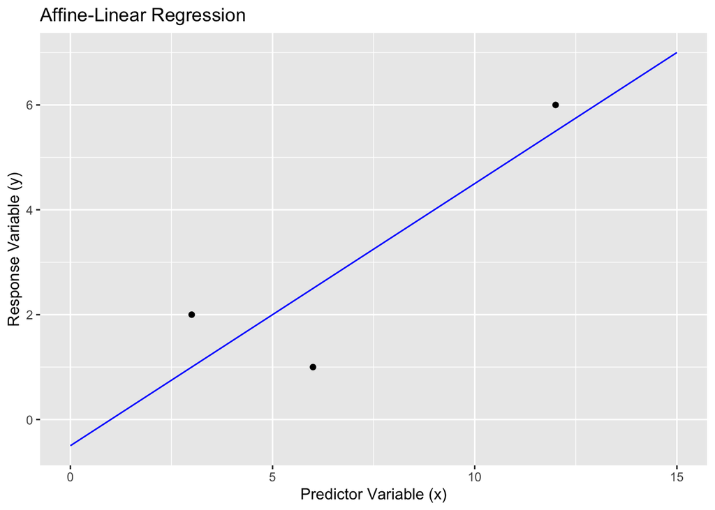

```r
#Set lm model
model <- lm(y ~ x, data = df)
x_seq <- seq(0, 15, by = 0.1)
y_pred <- predict(model, data.frame(x = x_seq))
#Plot model
ggplot(df, aes(x,y)) +
  geom_point() +
  geom_line(data = data.frame(x = x_seq, y = y_pred), aes(x, y), color = "blue") +
  labs(title = "Affine-Linear Regression",
       x = "Predictor Variable (x)",
       y = "Response Variable (y)")
```

### (d)

```r
#Add the test point
test_df <- data.frame(x = 8, y = 2)
#Compute the MSE for f0
f0_train <- rep(3,nrow(df))
f0_test <- rep(3, nrow(test_df))
train_mse_f0 <-  mean((f0_train - df$y)^2)
test_mse_f0 <- mean((f0_test - test_df$y)^2)
#Compute the MSE for f1
f1_train <- beta0 + beta1 * df$x
f1_test <- beta0 + beta1 * test_df$x
train_mse_f1 <- mean((f1_train- df$y)^2)
test_mse_f1 <- mean((f1_test - test_df$y)^2)
# Print
cat("Training-MSE for f0:", train_mse_f0, "\n")
```

```
## Training-MSE for f0: 4.666667
```

```r
cat("Test-MSE for f0:", test_mse_f0, "\n")
```

```
## Test-MSE for f0: 1
```

```r
cat("Training-MSE for f1:", train_mse_f1, "\n")
```

```
## Training-MSE for f1: 1.166667
```

```r
cat("Test-MSE for f1:", test_mse_f1, "\n")
```

```
## Test-MSE for f1: 2.25
```

## Question 2.

### kNN function

```r
##kNN regression function
kNN <- function(k,x.train,y.train,x.pred) {
#
## This is kNN regression function for problems with
## 1 predictor
#
## INPUTS
#
# k       = number of observations in nieghbourhood
# x.train = vector of training predictor values
# y.train = vector of training response values
# x.pred  = vector of predictor inputs with unknown
#           response values
#
## OUTPUT
#
# y.pred  = predicted response values for x.pred

## Initialize:
n.pred <- length(x.pred);       y.pred <- numeric(n.pred)

## Main Loop
for (i in 1:n.pred){
  d <- abs(x.train - x.pred[i])
  dstar = d[order(d)[k]]
  y.pred[i] <- mean(y.train[d <= dstar])
}
## Return the vector of predictions
invisible(y.pred)
}
```

### (a)

```r
# Load the AutoTrain.csv and AutoTest.csv data sets
auto_train <- read.csv("AutoTrain.csv")
auto_test <- read.csv("AutoTest.csv")
# Set X and Y variables
train_xvals <- auto_train$weight
train_yvals <- auto_train$horsepower
test_xvals <- auto_test$weight
test_yvals <- auto_test$horsepower
kNN(2, train_xvals, train_yvals, test_xvals)
# Perform kNN regression for k = 2, 5, 10, 20, 30, 50, and 100
ks <- c(2, 5, 10, 20, 30, 50, 100)
regr_train <- rep(0, length(ks))
regr_test <- rep(0, length(ks))
for (i in 1:length(ks)) {
  # compute train MSE for k:
  y_train_pred <- kNN(ks[i], train_xvals, train_yvals, train_xvals) # predict response of train_xvals, when trained with (train_xvals,train_yvals)
  regr_train[i] <- mean((y_train_pred - train_yvals)^2) # compute MSE by taking the mean of square errors
  cat("The training MSE for k=", ks[i],"is ",  regr_train[i], "\n")

  # compute test MSE for k:
  y_test_pred <- kNN(ks[i], train_xvals, train_yvals, test_xvals) # predict response of test_xvals, when trained with (train_xvals,train_yvals)
  regr_test[i] <- mean((y_test_pred - test_yvals)^2) # compute MSE by taking the mean of square errors
  cat("The test MSE for k=", ks[i],"is ", regr_test[i], "\n")
}
```

```
## The training MSE for k= 2 is  239.5157
## The test MSE for k= 2 is  362.2768
## The training MSE for k= 5 is  337.0298
## The test MSE for k= 5 is  345.1861
## The training MSE for k= 10 is  386.0902
## The test MSE for k= 10 is  335.2254
## The training MSE for k= 20 is  395.0116
## The test MSE for k= 20 is  311.2487
## The training MSE for k= 30 is  403.2436
## The test MSE for k= 30 is  318.8864
## The training MSE for k= 50 is  419.3068
## The test MSE for k= 50 is  348.0813
## The training MSE for k= 100 is  597.4263
## The test MSE for k= 100 is  507.7263
```

### (b)

```r
cbind(ks, regr_train, regr_test)
```

```
##       ks regr_train regr_test
## [1,]   2   239.5157  362.2768
## [2,]   5   337.0298  345.1861
## [3,]  10   386.0902  335.2254
## [4,]  20   395.0116  311.2487
## [5,]  30   403.2436  318.8864
## [6,]  50   419.3068  348.0813
## [7,] 100   597.4263  507.7263
```

Based on the computed MSE values for different values of k, we can see that k=20 has the lowest test MSE of 311.2487. This means that the kNN regression model with k=20 performed the best for predicting the horsepower based on the weight of the cars in the test data.

### (c)

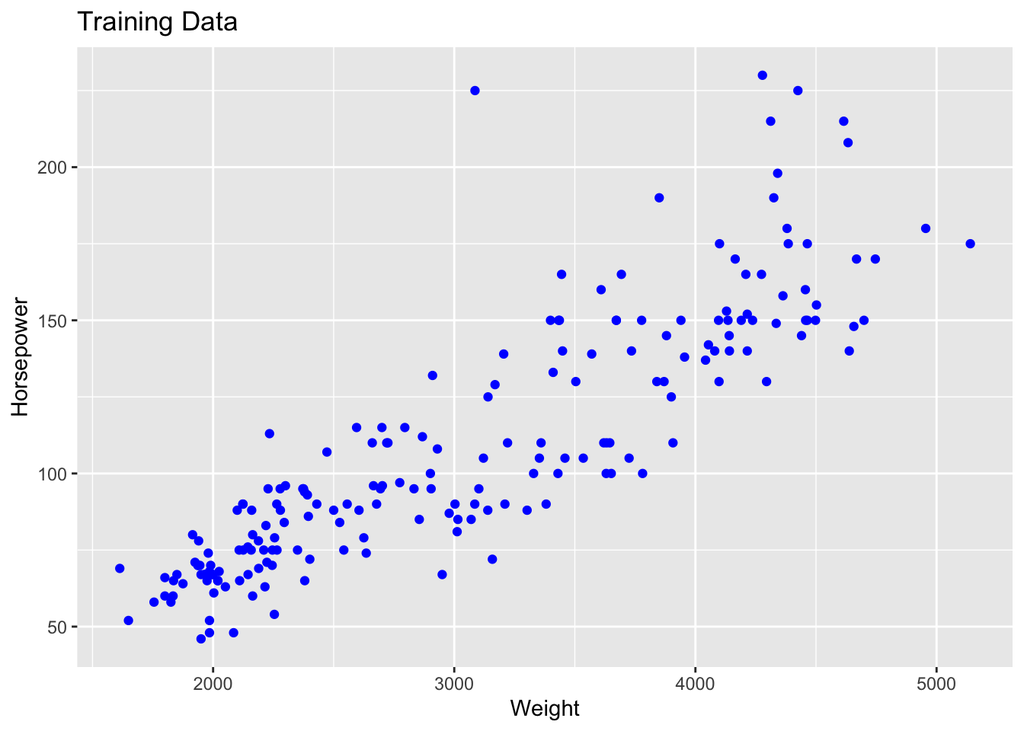

```r
# Find the best k value
best_k <- ks[which.min(regr_test)]

# Plot training data
train_plot <- ggplot(auto_train, aes(x = weight, y = horsepower)) +
  geom_point(color = "blue") +
  labs(x = "Weight", y = "Horsepower") +
  ggtitle("Training Data")
train_plot
```

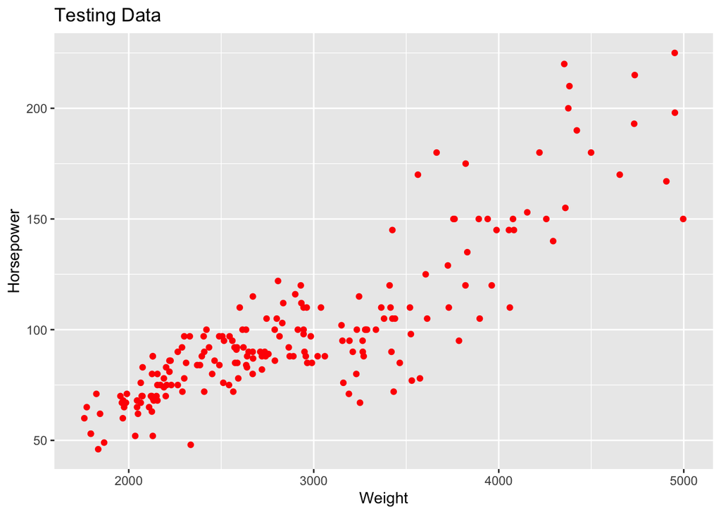

```r
# Plot testing data
test_plot <- ggplot(auto_test, aes(x = weight, y = horsepower)) +
  geom_point(color = "red") +
  labs(x = "Weight", y = "Horsepower") +
  ggtitle("Testing Data")
test_plot
```

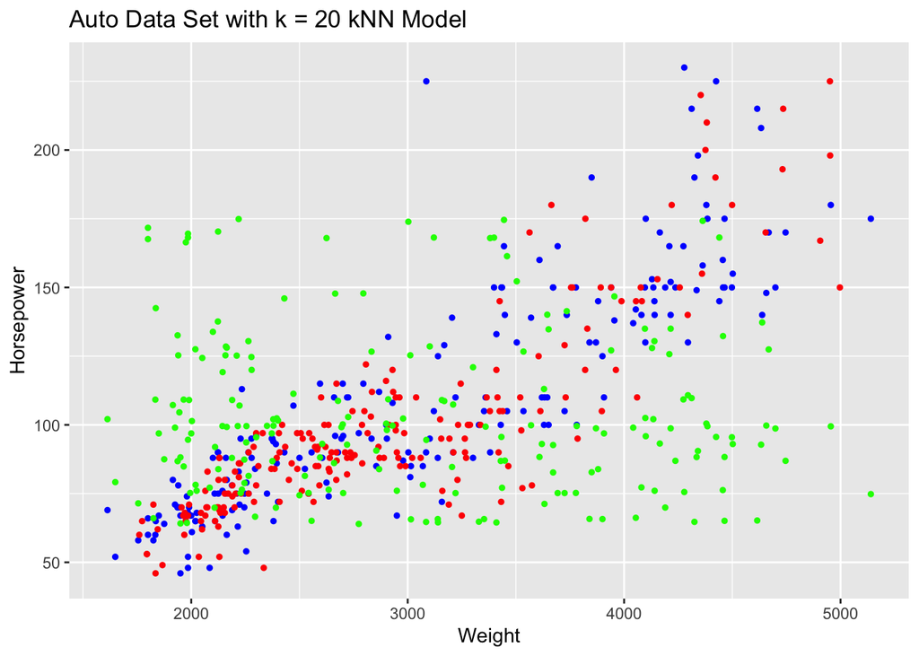

```r
# Plot training data, testing data and  best kNN model  in the same figure.
model <- kknn(horsepower ~ weight, train = auto_train, test = auto_test, k = best_k)
knn_data <- data.frame(weight = auto_train$weight, horsepower = model$fitted.values)
knn_data <- knn_data[order(knn_data$weight), ]
p <- ggplot() + geom_point(aes(x = weight, y = horsepower), data = auto_train, color = "blue", size = 1) +
  geom_point(aes(x = weight, y = horsepower), data = auto_test, color = "red", size = 1) +
  geom_point(aes(x = weight, y = horsepower), data = knn_data, color = "green", size = 1) +
  ggtitle(paste0("Auto Data Set with k = ", best_k, " kNN Model")) +
  labs(x = "Weight", y = "Horsepower")

# Print the plot
print(p)
```

### (d)

The kNN regression model has a trade-off between bias and variance. As we increase the value of k, the model becomes less flexible and has a higher bias but lower variance. On the other hand, when k is small, the model is more flexible and has a lower bias but higher variance. A common approach is to use cross-validation to estimate the test error for different values of k and choose the value that minimizes the test error.